# Medicare at 65: Employment and Covariate Balance

Continuity checks around the eligibility threshold

## Study and specification

The current file contains **69,622 respondents from 1992-1996**, aged 55.25-74.75. It does not yet cover the proposed 1992-2003 period. Missing doctor-visit outcomes were removed upstream. Other missing outcomes are excluded separately for each test.

We estimate local linear regressions within **five years of 65**, with separate age slopes on either side, survey-year fixed effects, NHIS survey weights and a triangular kernel. Three- and seven-year windows provide sensitivity checks. Bandwidths are fixed in years because age is measured in quarters. Survey-weighted percentages give respondents influence proportional to their population weights; the kernel gives greater influence to ages near 65.

$$Y_i=\alpha+\tau
1(Age_i\ge65)+\beta(Age_i-65)
+\delta
1(Age_i\ge65)(Age_i-65)+\lambda_{year(i)}+\varepsilon_i.$$

The project’s primary estimand is the local intention-to-treat effect of Medicare eligibility on seeing a doctor in the past year, with a fuzzy LATE as an extension. Interpreting the age-65 jump as an eligibility effect requires other determinants to remain smooth. Independent retirement incentives at 65 could instead make it a combined effect of turning 65. Medicare-induced retirement can be part of the eligibility effect. Employment is therefore a central diagnostic, although smooth employment alone cannot establish identification.

## Employment at 65

The estimated employment jump is **0.73 percentage points** (95% CI [-1.43, 2.89]; p = 0.507). The fitted employment rate immediately below 65 is 27.0%, giving a relative change of 2.7%. There is no statistically significant employment jump in the main specification. The confidence interval nevertheless allows retirement effects that may matter economically.

| Specification | Jump (pp) | 95% CI (pp) | p-value | N |
| --- | --- | --- | --- | --- |
| +/-5 years | 0.73 | [-1.43, 2.89] | 0.507 | 34,972 |
| +/-3 years | 1.16 | [-1.64, 3.96] | 0.418 | 20,726 |
| +/-7 years | -0.58 | [-2.40, 1.25] | 0.537 | 49,016 |

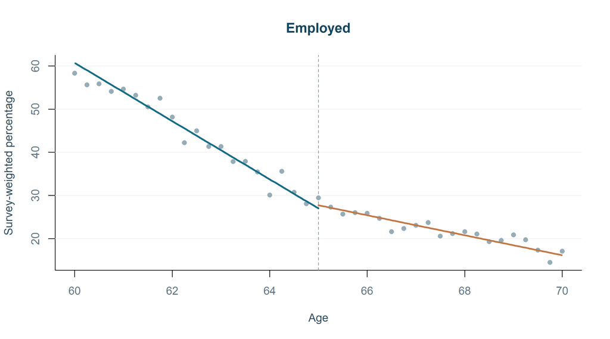

Employment around age 65. Points are weighted quarter-age means; curves are local linear fits.

Dots show quarter-age percentages; lines show five-year local fits standardized to the same year distribution on both sides.

## Covariate balance

We check sex, race/ethnicity, below-high-school education and region. Redundant education measures and one indicator from each exhaustive race and region set are omitted. Region codes follow the input data.

| Specification | Jump (pp) | 95% CI (pp) | p-value | N | Holm p-value |
| --- | --- | --- | --- | --- | --- |
| Female | -0.92 | [-3.30, 1.47] | 0.451 | 34,972 | 1 |
| White non-Hispanic | 0.28 | [-1.51, 2.07] | 0.758 | 34,972 | 1 |
| Black non-Hispanic | 0.21 | [-1.07, 1.49] | 0.746 | 34,972 | 1 |
| Hispanic | -0.16 | [-1.12, 0.79] | 0.737 | 34,972 | 1 |
| Below high school | 0.59 | [-1.61, 2.78] | 0.599 | 34,468 | 1 |
| Region 1 | 0.66 | [-1.29, 2.61] | 0.508 | 34,972 | 1 |
| Region 2 | -1.22 | [-3.24, 0.80] | 0.236 | 34,972 | 1 |
| Region 3 | 1.63 | [-0.64, 3.90] | 0.160 | 34,972 | 1 |

Of the 8 tests, 0 reject zero at 5% before multiple-testing adjustment and 0 after Holm adjustment. These are individual tests, not a joint test or proof of continuity. Education is missing for 1021 respondents in the full sample; that test uses its own available observations.

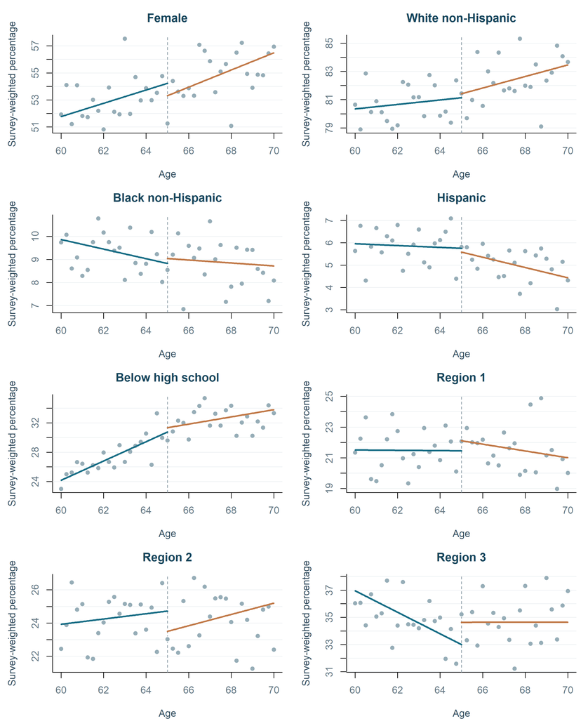

Covariate profiles using the main five-year bandwidth.

## Employment robustness

The donut specification excludes observations less than a quarter-year from 65, including those coded exactly 65. Placebos at 60 and 70 use three-year windows that exclude the actual eligibility threshold. These checks concern employment; utilisation robustness is estimated separately.

| Specification | Jump (pp) | 95% CI (pp) | p-value | N |
| --- | --- | --- | --- | --- |
| Donut: exclude \|age-65\| < 0.25 | 0.11 | [-2.15, 2.38] | 0.922 | 34,071 |
| Placebo at 60 (+/-3 years) | 1.89 | [-1.16, 4.94] | 0.225 | 21,344 |
| Placebo at 70 (+/-3 years) | -0.05 | [-2.43, 2.33] | 0.967 | 19,318 |

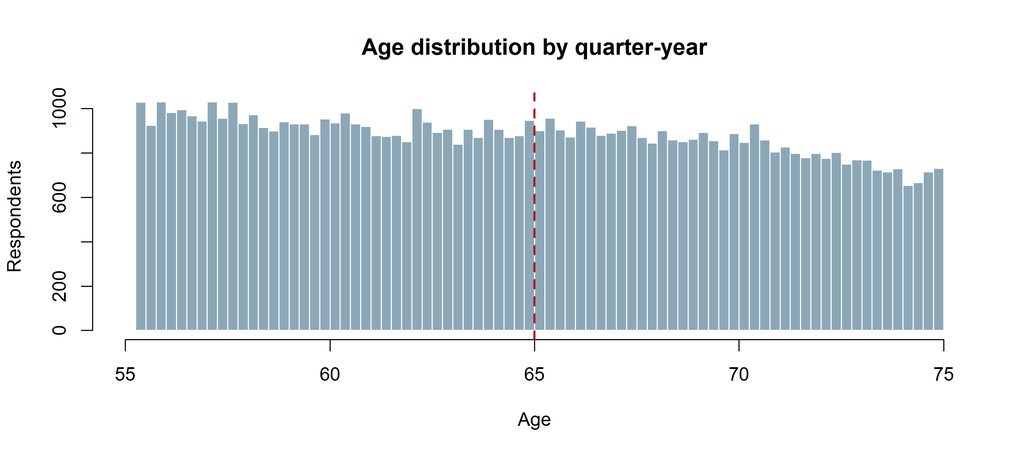

## Interpretation

Employment and balance results provide evidence about comparability around 65, conditional on observed doctor-visit responses. They cannot establish continuity of unobserved outcomes or test selection from missing doctor-visit responses. HC1 confidence intervals are approximate: they do not correct smoothing bias, limited quarterly age support, or the full NHIS survey design.

The project’s main outcome remains seeing a doctor, with hospital stays secondary and self-rated health excluded. Attribution to Medicare depends on the employment evidence and race-by-education pattern, rather than the cutoff alone. If independent retirement effects remain, the age-65 jump combines Medicare and retirement effects, and a fuzzy estimate rescales that jump. Calling the fuzzy estimate an upper bound additionally requires a positive retirement effect on utilisation, a positive first stage and no offsetting exclusion violations. A fuzzy extension uses one clearly defined first-stage treatment: any insurance measures gaining coverage, while Medicare enrollment also includes insurance switching. Those utilisation and subgroup estimates are outside this employment and balance report.

Card, D., Dobkin, C. and Maestas, N. (2008). [The Impact of Nearly Universal Insurance Coverage on Health Care Utilization: Evidence from Medicare](https://pmc.ncbi.nlm.nih.gov/articles/PMC2600774/). *American Economic Review*, 98(5), 2242-2258.